# Practical Machine Learning Project

# Background

Using devices such as Jawbone Up, Nike FuelBand, and Fitbit it is now possible to collect a large amount of data about personal activity relatively inexpensively. These type of devices are part of the quantified self movement - a group of enthusiasts who take measurements about themselves regularly to improve their health, to find patterns in their behavior, or because they are tech geeks. One thing that people regularly do is quantify how much of a particular activity they do, but they rarely quantify how well they do it. In this project, your goal will be to use data from accelerometers on the belt, forearm, arm, and dumbell of 6 participants. They were asked to perform barbell lifts correctly and incorrectly in 5 different ways. More information is available from the website here: http://groupware.les.inf.puc-rio.br/har (see the section on the Weight Lifting Exercise Dataset).

# Functions

```r
# Total de Na's en todas las columnas para analizar si eliminar los registros o hacer reemplazo de valores
verificarNas <- function(df){

    nas <- c()
    for (i in 1:ncol(df)){

        nas <- c(nas,round(mean(is.na(df[,i])),3))

    }
    nas <- data.frame(nas)
    nas$Numero <- 1:ncol(df)
    nas$Nombre <- names(df)
    nas <- nas[nas$nas>0,c(2,3,1)]
    nas

}
```

# Data Processing

First I need to load some packages

```r
library(caret)
library(rpart)
library(rpart.plot)
library(randomForest)
library(corrplot)
library(corrgram)
```

## Load the data

I have the data in a local folder.

```r
test <- read.csv("pml-testing.csv")
train <- read.csv("pml-training.csv")
```

I want to verify the dimensions of the datasets

```r
dim(train)
```

```
[1] 19622   160
```

The train set has 19622 rows and 160 features.

```r
dim(test)
```

```
[1]  20 160
```

The test set has 20 rows and 160 features

## Clean the data

I will clean the data analyzing the missing values.

```r
nas <- verificarNas(train)
nas
```

|  | Numero | Nombre | nas |
| --- | --- | --- | --- |
| 18 | 18 | max_roll_belt | 0.979 |
| 19 | 19 | max_picth_belt | 0.979 |
| 21 | 21 | min_roll_belt | 0.979 |
| 22 | 22 | min_pitch_belt | 0.979 |
| 24 | 24 | amplitude_roll_belt | 0.979 |
| 25 | 25 | amplitude_pitch_belt | 0.979 |
| 27 | 27 | var_total_accel_belt | 0.979 |
| 28 | 28 | avg_roll_belt | 0.979 |
| 29 | 29 | stddev_roll_belt | 0.979 |
| 30 | 30 | var_roll_belt | 0.979 |

[output cut: 57 more lines]

As we can see there are 67 features that have a lot of missing values - 97,9%. So I will remove them from the data set.

```r
vars <- nas$Numero
train <- train[,-vars]
test <- test[,-vars]
nas <- verificarNas(test)
vars <- nas$Numero
train <- train[,-vars]
test <- test[,-vars]
```

Also I should clean the variables that don’t contribute to the measurements.

```r
classe <- train$classe
trainRemove <- grepl("^X|timestamp|window|id", names(train))
train <- train[, !trainRemove]
train <- train[, sapply(train, is.numeric)]
train$classe <- classe
testRemove <- grepl("^X|timestamp|window|id", names(test))
test <- test[, !testRemove]
test <- test[, sapply(test, is.numeric)]
```

## Split

I will split the data using 70% for training and 30% for test.

```r
set.seed(1204)
inTrain <- createDataPartition(train$classe, p=0.70, list=F)
trainData <- train[inTrain, ]
testData <- train[-inTrain, ]
```

# Modeling

In this model we want to predict the activity that the person is doing. So I will use Random forest because is very powerfull for this use case.

```r
controlRf <- trainControl(method="cv", 5)
modelRf <- train(classe ~ ., data=trainData, method="rf", trControl=controlRf, ntree=200)
modelRf
```

```
Random Forest

13737 samples
   52 predictor
    5 classes: 'A', 'B', 'C', 'D', 'E'

No pre-processing
Resampling: Cross-Validated (5 fold)
Summary of sample sizes: 10990, 10989, 10990, 10989, 10990
Resampling results across tuning parameters:

  mtry  Accuracy   Kappa
   2    0.9897354  0.9870130
  27    0.9903178  0.9877500
  52    0.9857319  0.9819475

Accuracy was used to select the optimal model using the largest value.
The final value used for the model was mtry = 27.
```

```r
predictRf <- predict(modelRf, testData)
confusionMatrix(testData$classe, predictRf)
```

```
Confusion Matrix and Statistics

          Reference
Prediction    A    B    C    D    E
         A 1674    0    0    0    0
         B    9 1123    7    0    0
         C    0    3 1020    3    0
         D    0    0   12  952    0
         E    0    0    1    1 1080

Overall Statistics

               Accuracy : 0.9939
                 95% CI : (0.9915, 0.9957)
    No Information Rate : 0.286
    P-Value [Acc > NIR] : < 2.2e-16

                  Kappa : 0.9923
 Mcnemar's Test P-Value : NA

Statistics by Class:

                     Class: A Class: B Class: C Class: D Class: E
Sensitivity            0.9947   0.9973   0.9808   0.9958   1.0000
Specificity            1.0000   0.9966   0.9988   0.9976   0.9996
Pos Pred Value         1.0000   0.9860   0.9942   0.9876   0.9982
Neg Pred Value         0.9979   0.9994   0.9959   0.9992   1.0000
Prevalence             0.2860   0.1913   0.1767   0.1624   0.1835
Detection Rate         0.2845   0.1908   0.1733   0.1618   0.1835
Detection Prevalence   0.2845   0.1935   0.1743   0.1638   0.1839
Balanced Accuracy      0.9973   0.9970   0.9898   0.9967   0.9998
```

```r
accuracy <- postResample(predictRf, testData$classe)
accuracy
```

```
 Accuracy     Kappa
0.9938828 0.9922612
```

```r
oose <- 1 - as.numeric(confusionMatrix(testData$classe, predictRf)$overall[1])
oose
```

```
[1] 0.006117247
```

The results are that the accuracy of the model is 99.39% and the out of sample error is 0.61%.

# Predictions

```r
result <- predict(modelRf, test)
result
```

```
 [1] B A B A A E D B A A B C B A E E A B B B
Levels: A B C D E
```

# Visualization

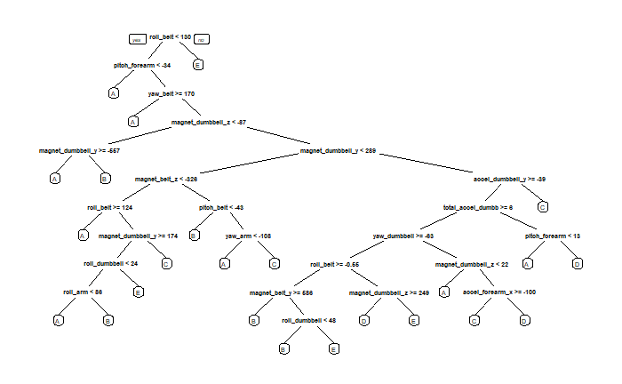

```r
treeModel <- rpart(classe ~ ., data=trainData, method="class")
prp(treeModel)
```